# Tarea1_andrey_arguedas

## Tarea #1 Minería de Datos

## Autor : Andrey Arguedas Espinoza

### 1. Dado x = (3,−5,31,−1,−9,10,0,18) y dado y = (1,1,−3,1,−99,−10,10,−7) realice lo siguiente:

#### • Introduzca x y y como listas en Python.

```python
x = [3,-5,31,-1,-9,10,0,18]
y = [1,1,-3,1,-99,-10,10,-7]

print(x)
print(y)
```

```
[3, -5, 31, -1, -9, 10, 0, 18]
[1, 1, -3, 1, -99, -10, 10, -7]
```

#### • Calcule la media, la varianza y la desviación est´andar de y.

```python
import math

def media(lista):
    return sum(lista) / len(lista)

def varianza(lista):
    acum = 0
    med = media(lista)
    for i in lista:
        acum += (i - med) ** 2
    return acum / len(lista)

def desviacion(lista):
    return math.sqrt(varianza(lista))

print("Media ", media(y))
print("Varianza ",varianza(y))
print("Desviacion estandar ", desviacion(y))
```

```
Media  -13.25
Varianza  1082.1875
Desviacion estandar  32.89661836724255
```

#### • Calcule la media, la varianza y la desviacio´n est´andar de x.

```python
print("Media ", media(x))
print("Varianza ",varianza(x))
print("Desviacion estandar ", desviacion(x))
```

```
Media  5.875
Varianza  153.109375
Desviacion estandar  12.373737309317667
```

#### •Calcule la correlación entre x y y

```python
import numpy as np

np.corrcoef(x, y)
```

```
array([[1.        , 0.36596793],
       [0.36596793, 1.        ]])
```

#### • Escriba comandos en Python para extraer las entradas 2 a la 7 de x.

```python
x[2:8]
```

```
[31, -1, -9, 10, 0, 18]
```

#### • Escriba comandos en Python para extraer las entradas de y excepto la 2 y la 7.

```python
list(filter(lambda e : y.index(e) not in (2, 7), y))
```

```
[1, 1, 1, -99, -10, 10]
```

#### • Escriba comandos en Python para extraer las entradas de y menores a -3 o mayores a 10.

```python
list(filter(lambda x: x < -3 or x > 10, y))
```

```
[-99, -10, -7]
```

#### • Escriba comandos en Python para extraer las entradas de x mayores a 0 y que sean n´umeros pares

```python
list(filter(lambda e: e > 0 and e % 2 == 0, x))
```

```
[10, 18]
```

### 2. Usando c´odigo Python (no archivos) en un DataFrame la siguiente tabla de datos:

Peso Edad Nivel Educativo 76 25 Lic 67 23 Bach 55 19 Bach 57 18 Bach 87 57 Dr 48 13 MSc

```python
import pandas as pd

datos = {'Peso': [76, 67, 55, 57, 87, 48],
         'Edad': [25, 23, 19, 18, 57, 13],
         'Nivel Educativo': ["Lic", "Bach", "Bach", "Bach", "Dr", "MSc"]
         }
datos_pandas = pd.DataFrame(datos)
print(datos_pandas)
```

```
   Peso  Edad Nivel Educativo
0    76    25             Lic
1    67    23            Bach
2    55    19            Bach
3    57    18            Bach
4    87    57              Dr
5    48    13             MSc
```

### 3. Genere una hoja de datos (“data frame”) a partir de la siguiente tabla de datos y verifique que las variables tengan el tipo de dato adecuado.

id: Identificador ´unico del estudiante.

calificacion: Nota o calificaci´on obtenida en una escala descendente de la A a la D.

duracion: Cantidad de minutos requeridos para realizar la prueba.

id calificacion duracion 1 B 64 2 C 85 3 B 76 4 A 83 5 A 80 6 A 78 7 C 68 8 B 82 9 A 89 10 B 61

```python
import pandas as pd
import numpy as np
datos = {'calificacion': ["B", "C", "B", "A", "A", "A", "C", "B", "A", "B"],
         'duracion': [64, 85, 76, 83, 80, 78, 68, 82, 89, 61]
         }
datos_pandas = pd.DataFrame(datos)
datos_pandas.index = np.arange(1,len(datos_pandas)+1)
datos_pandas.index.name = "id"
print(datos_pandas)
```

```
   calificacion  duracion
id
1             B        64
2             C        85
3             B        76
4             A        83
5             A        80
6             A        78
7             C        68
8             B        82
9             A        89
10            B        61
```

### 4. Dado x = (24, 28, 29, 18, 95, 97, 90, 72, 87, 85, 74, 9, 40) realice las siguiente operaciones:

#### • Indique los ´ındices de los valores o entradas del vector cuya divisi´on entre 2 tiene como resultado 45.

```python
x = (24, 28, 29, 18, 95, 97, 90, 72, 87, 85, 74, 9, 40)
indices = []
for element in x:
    if element / 2 == 45:
        indices.append(x.index(element))

indices
```

```
[6]
```

#### •Indique el ´ındice del valor m´as alto del vector.

```python
x.index(max(x))
```

```
5
```

#### • Indique el resultado de la suma de los valores (entradas del vector) menores a la media del vector.

```python
from functools import reduce
import numpy as np

media = np.mean(x)

reduce((lambda x, y: x + y), list(filter(lambda e: e < media, x)))
```

```
148
```

#### • Utilizando el operador l´ogico and (“y”l´ogico) indique cu´ales los valores del vector que son mayores a la media del vector y que sean divisibles entre 2.

```python
media = np.mean(x)

list(filter(lambda e: e > media and e % 2 == 0, x))
```

```
[90, 72, 74]
```

### 5. Para las variables almacenadas de la siguiente forma v1 = (2,7,6,4,52), v2 = (7,5,7,0,1)) y v3 = (2,4,3,5,6) usando el comando sum calcule la sumatoria de cada una de esas variables. Repita lo anterior usando un for(...).

```python
v1 = (2,7,6,4,52)
v2 = (7,5,7,0,1)
v3 = (2,4,3,5,6)

print("Sum v1", sum(v1))

print("Sum v2", sum(v2))

print("Sum v3", sum(v3))

def suma(v):
    acum = 0
    for i in v:
        acum += i
    return acum

print("--------------------")

print("Suma v1", suma(v1))

print("Suma v2", suma(v2))

print("Suma v3", suma(v3))
```

```
Sum v1 71
Sum v2 20
Sum v3 20
--------------------
Suma v1 71
Suma v2 20
Suma v3 20
```

### 6. Dado x = (24, 28, 29, 18, 95, 97, 90, 72, 87, 85, 74, 9, 40) construya una lista llamada lista1 que tenga 3 campos Media, M´aximo y M´ınimo que tienen la media, el m´aximo y el m´ınimo respectivamente del vector x

```python
x = (24, 28, 29, 18, 95, 97, 90, 72, 87, 85, 74, 9, 40)
lista1 = [np.mean(x), max(x), min(x)]
print(lista1)
```

```
[57.53846153846154, 97, 9]
```

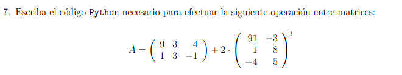

```python
import numpy as np

M1 = np.matrix([[9, 3, 4], [1, 3, -1]])
M2 = np.matrix([[91, -3], [1, 8], [-4, 5]])
A = M1 + 2 * np.transpose(M2)
print(A)
```

```
[[191   5  -4]
 [ -5  19   9]]
```

### 8. Cargue en un DataFrame el archivo EjemploAlgoritmosRecomendacion.csv y haga lo siguiente:

```python
import os
import pandas as pd
os.chdir("/Users/Andrey/Desktop/Data-Science-Course/II Lecture/Data")
datos_est = pd.read_csv('EjemploAlgoritmosRecomendacion.csv',delimiter=';',decimal=",",index_col=0)
print(datos_est)
```

```
             VelocidadEntrega  Precio  Durabilidad  ImagenProducto  \
Adam                     2.05    0.30         3.45            2.35
Anna                     0.90    1.50         3.15            3.30
Bernard                  1.70    2.60         2.85            3.00
Edward                   1.35    0.50         3.55            2.95
Emilia                   3.00    0.45         4.80            3.90
Fabian                   0.95    1.65         3.95            2.40
Philip                   2.30    1.20         4.75            3.30
Frank                    0.65    2.10         3.10            2.55
Xavier                   2.75    0.80         4.70            2.35
Gabriel                  2.00    1.75         3.25            3.00
Marisol                  1.20    0.80         4.40            2.40
Henry                    1.95    1.10         4.55            2.30
Irene                    1.40    0.70         4.05            1.90
Isabelle                 1.85    0.75         4.30            2.85
Isidore                  2.35    0.65         4.95            3.35
Joseph                   1.70    1.00         4.85            2.35
Eugene                   1.60    2.05         2.85            2.55
Eugenia                  2.45    0.90         3.85            2.15
Eunice                   2.65    0.70         4.85            3.05
Eva                      2.35    0.65         4.95            3.35
Evdokia                  1.65    0.45         4.30            2.00
Fedir                    1.70    0.20         4.15            1.25
Felix                    1.50    2.00         4.55            3.55
Fialka                   1.20    0.75         3.35            2.40
Flavia                   2.55    0.70         4.35            2.40
Flora                    2.30    1.05         3.95            2.90
Florent                  1.20    0.75         3.30            2.40
Florence                 2.60    0.65         4.85            3.05
Hannah                   1.75    1.40         4.95            1.75
Helen                    2.05    1.85         2.95            2.75
...                       ...     ...          ...             ...
Maximillian              1.80    2.70         2.95            3.10
Melania                  2.80    1.10         4.10            1.55
Methodius                1.80    1.10         4.95            2.40
Michael                  2.60    0.65         4.55            2.25
Michaelina               1.50    1.00         3.30            3.30
Mina                     2.10    1.20         4.70            2.45
Monica                   1.90    0.40         4.15            3.05
Mykyta                   1.65    1.30         4.85            1.65
```

[output cut: 135 more lines]

```
Sophia                   2.1
Stephan                  1.9
Stephania                4.5
Susanna                  3.4
Sylvan                   2.4
Sylvester                2.8
Tamara                   2.1
Theodore                 1.6
Teofan                   1.0
Teofil                   4.5
Teofila                  2.3
Teon                     2.7
Teresa                   1.8

[100 rows x 9 columns]
```

#### Calcule la dimensión de la Tabla de Datos.

```python
dimension = datos_est.shape
print("Dimension: " + str(dimension[0]) + " x " + str(dimension[1]))
```

```
Dimension: 100 x 9
```

#### Despliegue las primeras 2 columnas de la tabla de datos.

```python
print(datos_est.iloc[:,:2])
```

```
             VelocidadEntrega  Precio
Adam                     2.05    0.30
Anna                     0.90    1.50
Bernard                  1.70    2.60
Edward                   1.35    0.50
Emilia                   3.00    0.45
Fabian                   0.95    1.65
Philip                   2.30    1.20
Frank                    0.65    2.10
Xavier                   2.75    0.80
Gabriel                  2.00    1.75
Marisol                  1.20    0.80
Henry                    1.95    1.10
Irene                    1.40    0.70
Isabelle                 1.85    0.75
Isidore                  2.35    0.65
Joseph                   1.70    1.00
Eugene                   1.60    2.05
Eugenia                  2.45    0.90
Eunice                   2.65    0.70
Eva                      2.35    0.65
Evdokia                  1.65    0.45
Fedir                    1.70    0.20
Felix                    1.50    2.00
Fialka                   1.20    0.75
Flavia                   2.55    0.70
Flora                    2.30    1.05
Florent                  1.20    0.75
Florence                 2.60    0.65
Hannah                   1.75    1.40
Helen                    2.05    1.85
...                       ...     ...
Maximillian              1.80    2.70
Melania                  2.80    1.10
Methodius                1.80    1.10
Michael                  2.60    0.65
Michaelina               1.50    1.00
Mina                     2.10    1.20
Monica                   1.90    0.40
Mykyta                   1.65    1.30
```

[output cut: 9 more lines]

```
Sophia                   1.05    1.75
Stephan                  1.45    0.60
Stephania                2.15    1.25
Susanna                  1.50    1.40
Sylvan                   2.40    0.85
Sylvester                1.55    2.10
Tamara                   0.95    1.35
Theodore                 2.00    0.25
Teofan                   0.30    0.80
Teofil                   3.05    0.25
Teofila                  1.00    1.40
Teon                     1.55    1.10
Teresa                   1.25    0.90

[100 rows x 2 columns]
```

#### Ejecute un info() de los datos.

```python
datos_est.info()
```

```
<class 'pandas.core.frame.DataFrame'>
Index: 100 entries, Adam to Teresa
Data columns (total 9 columns):
VelocidadEntrega    100 non-null float64
Precio              100 non-null float64
Durabilidad         100 non-null float64
ImagenProducto      100 non-null float64
ValorEducativo      100 non-null float64
ServicioRetorno     100 non-null float64
TamanoPaquete       100 non-null float64
Calidad Producto    100 non-null float64
NumeroEstrellas     100 non-null float64
dtypes: float64(9)
memory usage: 7.8+ KB
```

#### Calcule la Media para todas las variables cualesquiera.

```python
import numpy as np
dictionary = {}
columns = datos_est.shape[1]
for i in range(0,columns):
    media = np.mean(datos_est.iloc[:,i])
    dictionary[datos_est.columns.values[i]] = media
print(dictionary)
```

[output not shown]

### 9. Cargue la tabla de datos que está en el archivo SAheartv.csv haga lo siguiente:

```python
import os
import pandas as pd
os.chdir("/Users/Andrey/Desktop/Data-Science-Course/II Lecture/Data")
pd.set_option('display.max_columns', 10)
pd.set_option('display.width', 1000)
datos_est = pd.read_csv('SAheart.csv',delimiter=';',decimal=".",index_col=0)
print(datos_est)
```

```
     tobacco    ldl  adiposity  famhist  typea  obesity  alcohol  age chd
sbp
160    12.00   5.73      23.11  Present     49    25.30    97.20   52  Si
144     0.01   4.41      28.61   Absent     55    28.87     2.06   63  Si
118     0.08   3.48      32.28  Present     52    29.14     3.81   46  No
170     7.50   6.41      38.03  Present     51    31.99    24.26   58  Si
134    13.60   3.50      27.78  Present     60    25.99    57.34   49  Si
132     6.20   6.47      36.21  Present     62    30.77    14.14   45  No
142     4.05   3.38      16.20   Absent     59    20.81     2.62   38  No
114     4.08   4.59      14.60  Present     62    23.11     6.72   58  Si
114     0.00   3.83      19.40  Present     49    24.86     2.49   29  No
132     0.00   5.80      30.96  Present     69    30.11     0.00   53  Si
206     6.00   2.95      32.27   Absent     72    26.81    56.06   60  Si
134    14.10   4.44      22.39  Present     65    23.09     0.00   40  Si
118     0.00   1.88      10.05   Absent     59    21.57     0.00   17  No
```

[output cut: 50 more lines]

#### • Calcule la dimensión de la Tabla de Datos.

```python
dimension = datos_est.shape
print("Dimension: " + str(dimension[0]) + " x " + str(dimension[1]))
```

```
Dimension: 462 x 9
```

#### • Despliegue las primeras 3 columnas de la tabla de datos

```python
print(datos_est.iloc[:,:3])
```

```
     tobacco    ldl  adiposity
sbp
160    12.00   5.73      23.11
144     0.01   4.41      28.61
118     0.08   3.48      32.28
170     7.50   6.41      38.03
134    13.60   3.50      27.78
132     6.20   6.47      36.21
142     4.05   3.38      16.20
114     4.08   4.59      14.60
114     0.00   3.83      19.40
132     0.00   5.80      30.96
206     6.00   2.95      32.27
134    14.10   4.44      22.39
118     0.00   1.88      10.05
```

[output cut: 50 more lines]

#### • Ejecute un info() de los datos.

```python
datos_est.info()
```

```
<class 'pandas.core.frame.DataFrame'>
Int64Index: 462 entries, 160 to 132
Data columns (total 9 columns):
tobacco      462 non-null float64
ldl          462 non-null float64
adiposity    462 non-null float64
famhist      462 non-null object
typea        462 non-null int64
obesity      462 non-null float64
alcohol      462 non-null float64
age          462 non-null int64
chd          462 non-null object
dtypes: float64(5), int64(2), object(2)
memory usage: 36.1+ KB
```

#### • Calcule la suma de las columnas con variables cuantitativas (numericas).

```python
import numpy as np
cuants = datos_est.select_dtypes(include=['float64', 'int64'])
dictionary = {}
for i in range(0, cuants.shape[1]):
    suma = np.sum(cuants.iloc[:,i])
    dictionary[cuants.columns.values[i]] = suma
print(dictionary)
```

```
{'tobacco': 1679.67, 'ldl': 2190.0299999999997, 'adiposity': 11737.91, 'typea': 24534, 'obesity': 12032.38, 'alcohol': 7874.509999999998, 'age': 19781}
```

#### • Calcule para todas las variables cuantitativas presentes en el archivo SAheart.csv:

```python
import numpy as np
dictionary = {}
cuants = datos_est.select_dtypes(include=['float64', 'int64'])
for i in range(0, cuants.shape[1]):
    minimo = np.min(cuants.iloc[:,i])
    maximo = np.max(cuants.iloc[:,i])
    media = np.mean(cuants.iloc[:,i])
    mediana = np.median(cuants.iloc[:,i])
    dictionary[cuants.columns.values[i]] = { 'Minimo' : minimo, 'Maximo' : maximo, 'Media' : media, 'Mediana' : mediana}

print(dictionary)
```

[output not shown]

### 10. Suponga que tenemos en una lista las notas de un estudiante en 3 exámenes, por ejemplo notas = (90,45,89), luego escriba instrucciones en Python para calcular el promedio y se despliegue “Ganó el curso” si la nota es mayor o igual a 67.5, “Extraordinario” si la nota es mayor o iguala 47.5 y menor a 67.5, “Perdió el curso” si la nota es menor a 47.5.

```python
notas = (90,45,89)
promedio = np.average(notas)
if promedio < 47.5:
    print("Perdió el curso")
elif promedio >= 47.5 and promedio < 67.5:
    print("Extraordinario")
elif promedio >= 67.5:
    print("Ganó el curso")
```

```
Ganó el curso
```

### 11. Escriba instrucciones en Python tal que dada la lista lista = (-9,-45,0,7,45,-100,89), calcule la suma de los números positivos, la suma de los números negativos en valor absoluto y al final despliegue la suma más grande.

```python
lista = (-9,-45,0,7,45,-100,89)
positivos = list(filter(lambda e: e >= 0, lista))
negativos = list(filter(lambda e: e < 0, lista))
negativos = list(map(lambda e: abs(e), negativos))
sumaPos = sum(positivos)
sumaNeg = sum(negativos)
if sumaPos > sumaNeg:
    print("Suma Positivos es mayor :", sumaPos)
elif sumaPos == sumaNeg:
    print("Sumas son iguales :", sumaPos)
else:
    print("Sumas Negativos es mayor :", sumaNeg)
```

```
Sumas Negativos es mayor : 154
```

### 12. Programe en Python una función que recibe dos valores, determinar cúal de los dos valores es el menor y luego lo retorna (no puede usar la función min de Python).

```python
def menor(v1, v2):
    return v1 if v1 <= v2 else v2

print("El menor de 34 y 87 es: ", menor(34, 87))
print("El menor de 541 y 5 es: ", menor(541, 5))
```

```
El menor de 34 y 87 es:  34
El menor de 541 y 5 es:  5
```

### 13. Programe en Python una función que recibe tres valores A, B, y C y retorna el menor (no puede usar la función min de Python).

```python
def menorDe3(a, b, c):
    minimum = menor(a, b)
    return c if c <= minimum else minimum

print("El menor de 34, 56 y 87 es: ", menorDe3(34, 56, 87))
```

```
El menor de 34, 56 y 87 es:  34
```

### 14. Programe en Python una función que recibe cuatro números y retorna el mayor (no puede usar la función max de Python).

```python
def mayor(v1, v2, v3, v4):
    argsExcFirst = (v2, v3, v4)
    maximum = v1
    for i in argsExcFirst:
        maximum = i if i >= maximum else maximum
    return maximum

mayor(58, 63, 1, 987)
```

```
987
```

### 15. Programe en Python una función que recibe un número n y retorna la sumatoria de los números enteros comprendidos entre el 1 y el n.

```python
def sumatoria(num):
    accum = 0
    for i in range(1, num):
        accum += i
    return accum

sumatoria(6)
```

```
15
```

### 16. Desarrolle una función que realice la sumatoria de los números enteros pares comprendidos entre el 1 y el n.

```python
def sumaPares(num):
    accum = 0
    for i in filter(lambda e: e %2 == 0, range(1, num)):
        accum += i
    return accum

sumaPares(6)
```

```
6
```

### 17. Desarrolle una función que realice la sumatoria de los números enteros múltiplos de 5, comprendidos entre el 1 y el n.

```python
def sumaMultiplos(num):
    accum = 0
    for i in filter(lambda e: e % 5 == 0, range(1, num)):
        accum += i
    return accum

sumaMultiplos(10)
```

```
5
```

### 18. Programe en Python una función que genera 200 números al azar entre 1 y 500 y luego calcula cúantos están entre el 50 y 450, ambos inclusive.

```python
def genRandNums():
    from random import randint
    nums = [randint(1, 500) for p in range(0, 200)]
    return len(list(filter(lambda e: e in range(50, 450), nums)))

genRandNums()
```

```
154
```

### 19. Desarrolle una función que calcula el costo de una llamada telefónica que ha durado t minutos sabiendo que si t < 1 el costo es de 0,4 dólares, mientras que para duraciones superiores el costo es de 0,4 + (t − 1)/4 dólares, la función debe recibir el valor de t.

```python
def calculaCosto(t):
    return 0.4 if t < 1 else 0.4 + (t - 1) / 4

print("El costo de una llamada de 0.9 minutos es: ", calculaCosto(0.9))
print("El costo de una llamada de 5 minutos es: ", calculaCosto(5))
```

```
El costo de una llamada de 0.9 minutos es:  0.4
El costo de una llamada de 5 minutos es:  1.4
```

### 20. Desarrolle una función que reciba un vector de números reales y un número real x, tal que indique el porcentaje de elementos menores o iguales a un valor x.

```python
def porcentajeMenores(vec, x):
    menores = list(filter(lambda e: e <= x, vec))
    return (len(menores) / len(vec)) * 100

vecPrueba = [ 4, 50, 147, 2, 35, 70, 94]
print("El porcentaje de #'s menores o iguales a 50 es :", porcentajeMenores(vecPrueba, 50))
```

```
El porcentaje de #'s menores o iguales a 50 es : 57.14285714285714
```

### 21. Desarrolle una función que reciba un número natural n (suponiendo que n > 1) y que construya y retorne un vector v de tamaño n tal que vk = vk−13 +0,5 para k = 2, . . . , n y siendo que v1 = 1.

```python
def construyeVec(n, vec = []):
    if n <= 1:
        vec.append(1)
        return vec
    else:
        result =  construyeVec(n - 1, vec)[-1] / 3 + 0.5
        vec.append(result)
        return vec

print("El resultado para k=4 es: ", construyeVec(4))
```

```
El resultado para k=4 es:  [1, 0.8333333333333333, 0.7777777777777777, 0.7592592592592593]
```

### 22. Desarrolle una función que recibe una matriz cuadrada A de tamaño n × n y calcula su traza, es decir, la suma de los elementos de la diagonal. Por ejemplo, la traza de la siguiente matriz:

### 9 3 4

### 1 3 −1

### 4 12 −2

### es 10.

```python
def traza(matriz):
    traza = 0
    for i in range(len(matriz)):
        traza += matriz[i][i]
    return traza

m1 = [[9, 3, 4], [1, 3, -1], [4, 12, -2]]
print("La traza es de: ", traza(m1))
```

```
La traza es de:  10
```

### 23. Desarrolle una función en Python que recibe un DataFrame que retorna la cantidad de entradas de este DataFrame que son divisibles entre 3 (Pruebe esta función leyendo un archivo de datos, esto en el Script de pruebas).

```python
import os
import pandas as pd
os.chdir("/Users/Andrey/Desktop/Data-Science-Course/II Lecture/Data")
pd.set_option('display.max_columns', 6)
pd.set_option('display.width', 1000)
data = pd.read_csv('EjemploEstudiantes.csv',delimiter=';',decimal=",",index_col=0)

def divisibles(datos):
    acum = 0
    for i in range(datos.shape[0]):
        for j in range(datos.shape[1]):
            if datos.iloc[i, j] % 3 == 0:
                acum += 1
    return acum;

print("El numero de divisibles entre 3 es: ",divisibles(data))
```

```
El numero de divisibles entre 3 es:  8
```

### 24. Desarrolle una función en Python que recibe un DataFrame y dos números de columna y que retorna en una lista con el nombre de las variables correspondientes a las columnas, la covarianza y la correlación entre esas dos variables (Pruebe esta función leyendo un archivo de datos, esto en el Script de pruebas).

```python
import os
import pandas as pd
os.chdir("/Users/Andrey/Desktop/Data-Science-Course/II Lecture/Data")
pd.set_option('display.max_columns', 6)
pd.set_option('display.width', 1000)
data = pd.read_csv('EjemploEstudiantes.csv',delimiter=';',decimal=",",index_col=0)

def covarianza(data, c1, c2):
    covar = data.iloc[:, c1].cov(data.iloc[:, c2])
    corre = data.iloc[:, c1].corr(data.iloc[:, c2])
    c1name = data.columns.values[c1]
    c2name = data.columns.values[c2]
    return {"Columna 1" : c1name, "Columna 2" : c2name, "Covarianza" : covar, "Correlacion" : corre}

covarianza(data, 0, 1)
```

```
{'Columna 1': 'Matematicas',
 'Columna 2': 'Ciencias',
 'Covarianza': 1.3083333333333333,
 'Correlacion': 0.8540787779257429}
```